# Práctica 10

Lucas Fehlau Arbulu

19-05-2022

# Aproximación de una probabilidad

```r
nsim <- 1000
set.seed(1)
x <- runif(nsim, -1, 1)
y <- runif(nsim, -1, 1)
suceso <- (x + y <= 0)
# Aproximación
mean(suceso)
```

```
## [1] 0.513
```

```r
# Error de estimación
sd(suceso) / sqrt(nsim)
```

```
## [1] 0.01581395
```

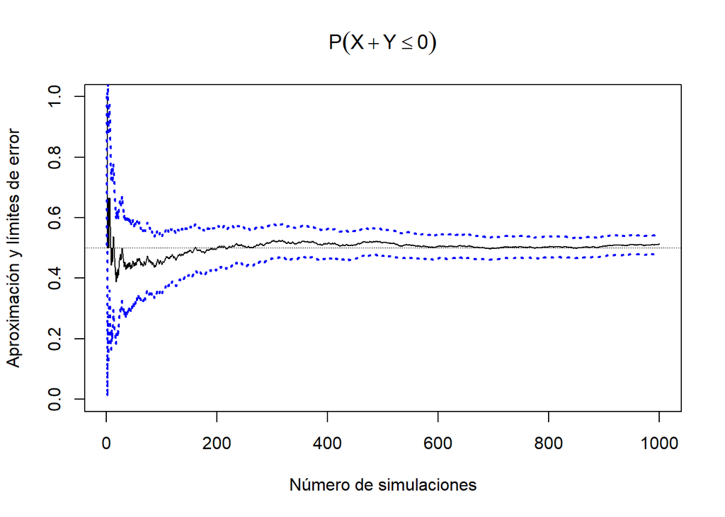

```r
## Gráfico de convergencia
# aproximaciones para $n=1,...,nsim$
estim <- cumsum(suceso) / (1:nsim)
# errores de estimación correspondientes
estim.err <- sqrt(cumsum((suceso - estim)^2)) / (1:nsim)
plot(1:nsim, estim,
    type = "l", ylab = "Aproximación y límites de error",
    xlab = "Número de simulaciones", main = expression(P(X + Y <= 0)),
    ylim = c(0, 1)
)
z <- qnorm(0.025, lower.tail = FALSE)
lines(estim - z * estim.err, col = "blue", lwd = 2, lty = 3)
lines(estim + z * estim.err, col = "blue", lwd = 2, lty = 3)
abline(h = 0.5, lwd = 0.5, lty = "dotted")
```

La probabilidad real es $1/2$, valor en el cual se ha sobrepuesto una recta horizontal. Observamos que se ajusta.

### Ejercicio:

(Enunciado) Aproximar mediante simulación la probabilidad $P(X^2 + Y^2 \leq 1)$. Compara con el valor exacto que vale $\pi/4$.

```r
nsim <- 1000
simular <- function(nsim, suceso, valor, seed = 1) {
}
set.seed(1)
x <- runif(nsim, -1, 1)
y <- runif(nsim, -1, 1)
suceso <- (x^2 + y^2 <= 1)
# Aproximación
mean(suceso)
```

```
## [1] 0.77
```

```r
# Error de estimación
sd(suceso) / sqrt(nsim)
```

```
## [1] 0.01331455
```

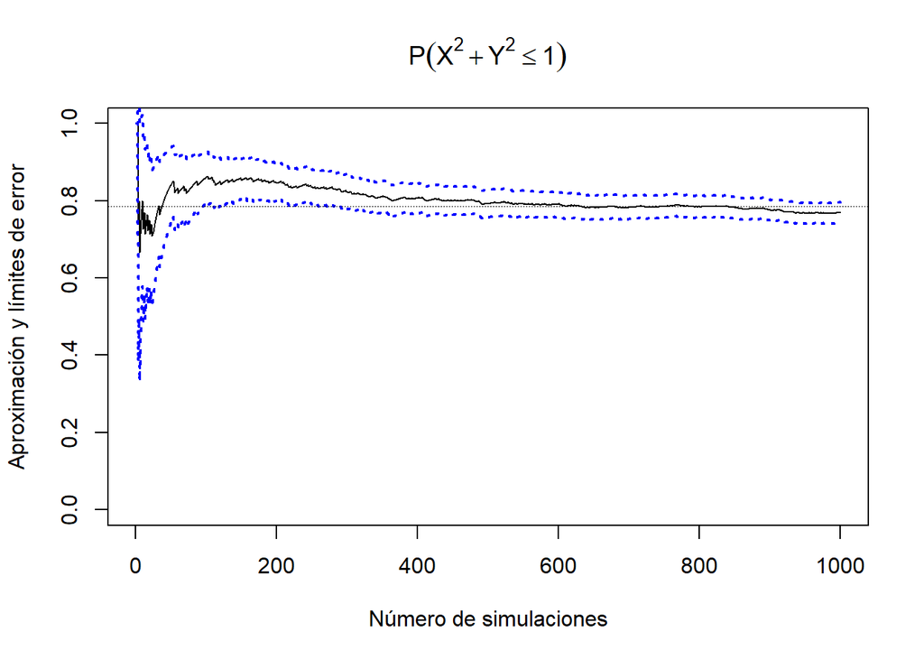

```r
## Gráfico de convergencia
# aproximaciones para $n=1,...,nsim$
estim <- cumsum(suceso) / (1:nsim)
# errores de estimación correspondientes
estim.err <- sqrt(cumsum((suceso - estim)^2)) / (1:nsim)
plot(1:nsim, estim,
    type = "l", ylab = "Aproximación y límites de error",
    xlab = "Número de simulaciones", main = expression(P(X^2 + Y^2 <= 1)),
    ylim = c(0, 1)
)
z <- qnorm(0.025, lower.tail = FALSE)
lines(estim - z * estim.err, col = "blue", lwd = 2, lty = 3)
lines(estim + z * estim.err, col = "blue", lwd = 2, lty = 3)
abline(h = pi / 4, lwd = 0.5, lty = "dotted")
```

# Aproximación de una integral

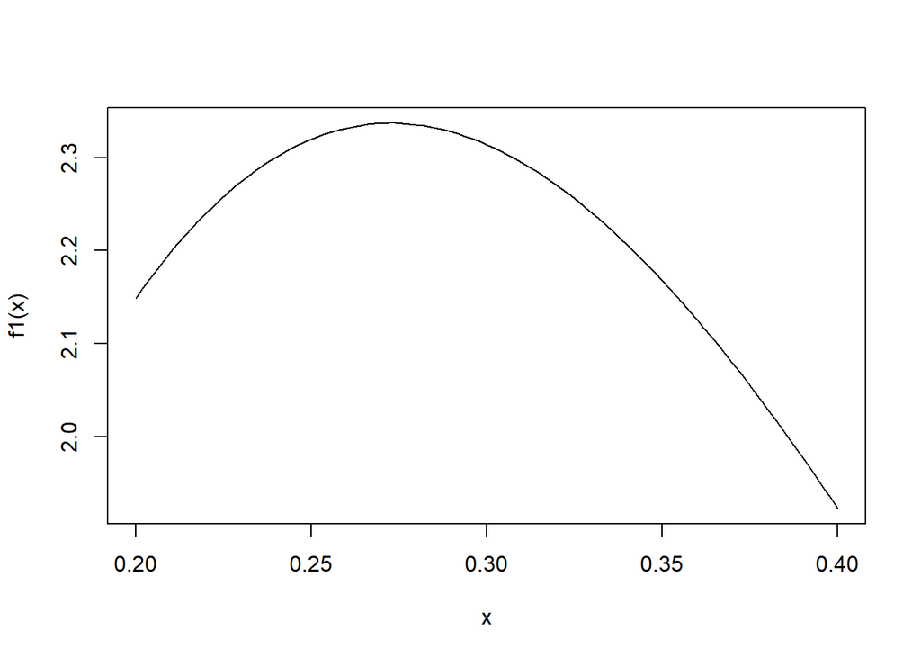

```r
# primera integral
a <- 2.5
b <- 5
f1 <- function(x) dbeta(x, a, b)
curve(f1(x), 0.2, 0.4)
```

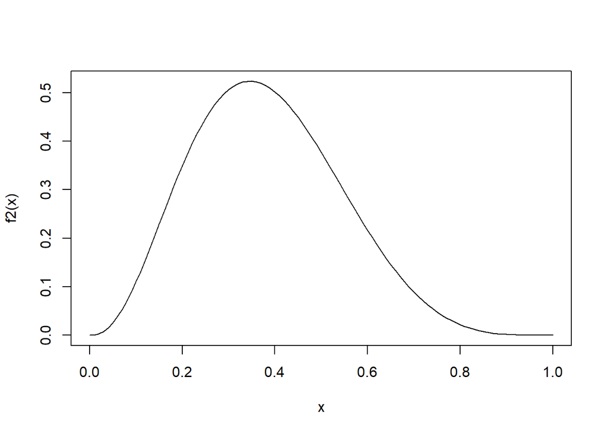

```r
# segunda integral
f2 <- function(x) sin(x) * exp(-x) * dbeta(x, a, b)
curve(f2(x), 0, 1)
```

### Objetivo: (Enunciado) Una vez visualizados los problemas, el objetivo es aproximar las dos integrales anteriores utilizando simulación. Para ello te sugiero que consideres $1000$ simulaciones. Además de la aproximación obtenida calcula su error de estimación y construye un gráfico que muestre la convergencia junto con los límites de error.

Vamos a ir comparando con el resultado de `integrate` directamente.

#### Primera integral:

```r
set.seed(1)
lim_inf <- 0.2
lim_sup <- 0.4
long <- lim_sup - lim_inf
nsim <- 1000
x <- runif(nsim, min = lim_inf, max = lim_sup)
f1x <- sapply(x, f1)
estim.integ <- f1x * long
```

Entonces la aproximación de la integral:

```r
mean(estim.integ)
```

```
## [1] 0.4443133
```

Comparada con el valor calculado numéricamente:

```r
integral <- integrate(f1, 0.2, 0.4)$value
integral
```

```
## [1] 0.4441656
```

```r
all.equal(integral, mean(estim.integ))
```

```
## [1] "Mean relative difference: 0.0003327116"
```

```r
# Error de estimación
sd(estim.integ) / sqrt(nsim)
```

```
## [1] 0.0007339457
```

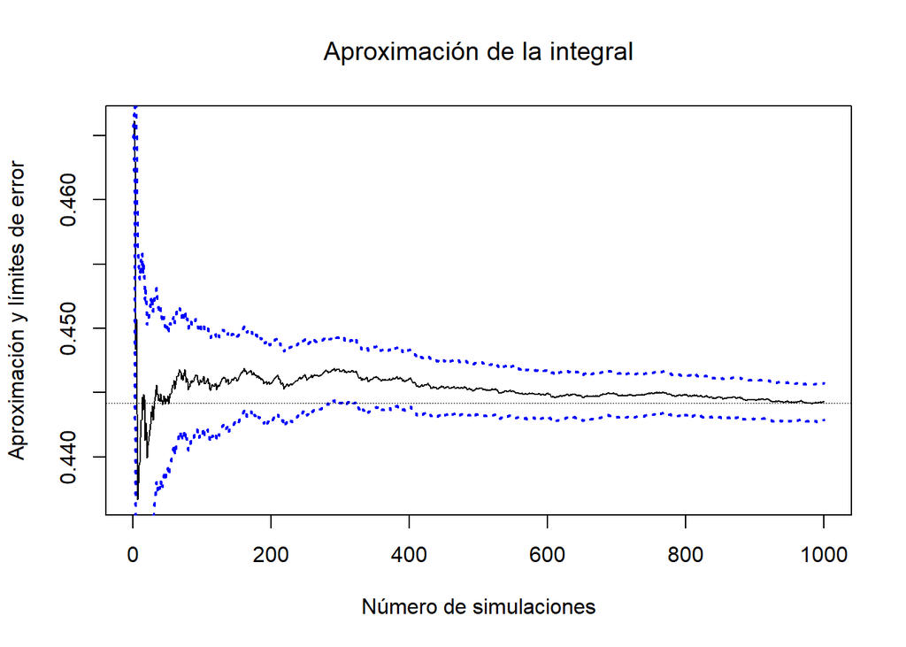

```r
## Gráfico de convergencia
# aproximaciones para $n=1,...,nsim$
estim <- (cumsum(estim.integ) / (1:nsim))
# errores de estimación correspondientes
estim.err <- sqrt(cumsum((estim.integ - estim)^2)) / (1:nsim)
plot(1:nsim, estim,
    type = "l", ylab = "Aproximación y límites de error",
    xlab = "Número de simulaciones",
    main = expression("Aproximación de la integral")
)
z <- qnorm(0.025, lower.tail = FALSE)
lines(estim - z * estim.err, col = "blue", lwd = 2, lty = 3)
lines(estim + z * estim.err, col = "blue", lwd = 2, lty = 3)
abline(h = integral, lwd = 0.5, lty = "dotted")
```

Donde la recta horizontal es el valor de la integral calculada numéricamente.

#### Segunda integral:

```r
x <- runif(nsim)
f2x <- sapply(x, f2)
```

Comparando con el valor calculado numéricamente:

```r
mean(f2x)
```

```
## [1] 0.2125689
```

```r
integral <- integrate(f2, 0, 1)$value
integral
```

```
## [1] 0.2172255
```

```r
all.equal(integral, mean(f2x))
```

```
## [1] "Mean relative difference: 0.021437"
```

```r
# Error de estimación
sd(f2x) / sqrt(nsim)
```

```
## [1] 0.006114361
```

Veamos el gráfico de convergencia y las aproximaciones para $n=1,...,n_{sim}$

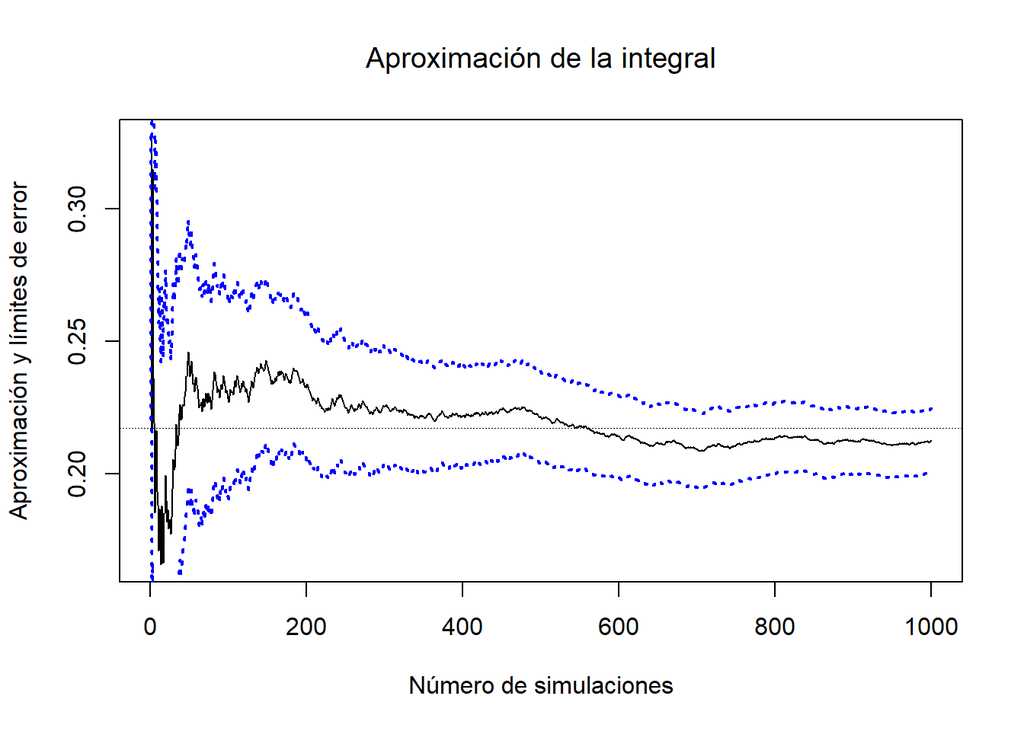

```r
estim <- cumsum(f2x) / (1:nsim)
# errores de estimación correspondientes
estim.err <- sqrt(cumsum((f2x - estim)^2)) / (1:nsim)
plot(1:nsim, estim,
    type = "l", ylab = "Aproximación y límites de error",
    xlab = "Número de simulaciones",
    main = expression("Aproximación de la integral")
)
z <- qnorm(0.025, lower.tail = FALSE)
lines(estim - z * estim.err, col = "blue", lwd = 2, lty = 3)
lines(estim + z * estim.err, col = "blue", lwd = 2, lty = 3)
abline(h = integral, lwd = 0.5, lty = "dotted")
```

De nuevo, la recta horizontal es el valor de la integral calculada numéricamente.

# Aproximación de una distribución de probabilidad

Supongamos que el número de reclamaciones a una aseguradora es $N\sim\mathcal{P}(17)$. Asociado a cada reclamación hay un pago $X_i$ con distribución lognormal con $\mu = 3.5$ y $\sigma = 1.1$. Entonces $S_n = \sum_{i=1}^N X_i$ es la cuantía total pagada por la aseguradora en un mes. Esta sería una distribución de Poisson compuesta.

Podemos calcular exactamente la media y varianza de $S_n$.

$$S_N = \sum_{i=1}^N X_i, \quad N\sim \mathcal{P}(\lambda)$$
Su esperanza y varianza vienen dadas, respectivamente, por
$$\begin{align*}
E[S_N] =& \,E[N]E[X_1] \\
Var[S_N] =& \,E[N]Var[X_1] + Var(N)E[X_1]^2
\end{align*}$$

Recordando que para una variable aleatoria $X$ con distribución lognormal $\mu, \sigma$,
$$\begin{align*}
E[X] =& \, \exp(\mu + \frac{\sigma^2}{2}) \\
Var[X] =& \, \left( \exp(\sigma^2) - 1 \right) \exp(2\mu +
\sigma^2) \\
=& \, \left(\exp(\sigma^2) - 1\right)E[X]^2
\end{align*}$$

Calculamos estos valores:

```r
# Parámetros de la lognormal (X)
mu <- 3.5
sig <- 1.1
# a partir de ellos calculamos E[X] y V(X)
EX <- exp(mu + sig^2 / 2)
EX
```

```
## [1] 60.64274
```

```r
VX <- EX^2 * (exp(sig^2) - 1)
VX
```

```
## [1] 8655.04
```

La esperanza y varianza de la Poisson compuesta serían:

```r
lambda <- 17 # parámetro de la Poisson. Coincide con E[N] y V(N)
# Media de la Poisson compuesta:
ES <- lambda * EX
ES
```

```
## [1] 1030.927
```

```r
# Varianza de la Poisson compuesta
VS <- lambda * VX + lambda * EX^2
VS
```

```
## [1] 209653.9
```

Ahora simulamos

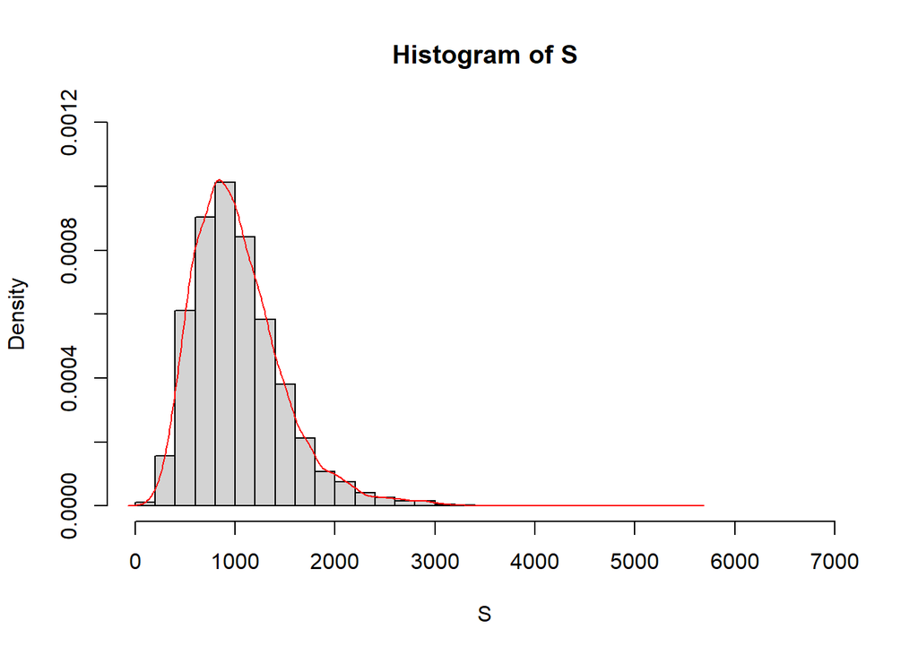

```r
nsim <- 5000 # número de simulaciones
# simulamos ahora nsim valores de S_N:
S <- double(nsim) # para almacenar los valores simulados
set.seed(1)
for (i in 1:nsim) {
    n <- rpois(1, lambda)
    # if (n > 0) {
    S[i] <- sum(rlnorm(n, mu, sig))
    # }
}
# el vector S contiene los valores simulados de S_N
# un histograma de S nos da una aproximación de la distribución
hist(S, xlim = c(0, 7000), breaks = 20, prob = TRUE, ylim = c(0, 1.2e-3))
# podemos superponer la densidad suavizada que calcula density()
lines(density(S), col = "red")
```

### Ejercicio:

(Enunciado) Calcula la media y la varianza de los `nsim` valores simulados de $S_N$. Estos nos dan aproximaciones de la media y la varianza exactas que calculamos antes de forma exacta.

```r
mean(S)
```

```
## [1] 1028.819
```

```r
var(S)
```

```
## [1] 206025.3
```

### Ejercicio:

(Enunciado) Utilizando los valores que hemos simulado de $S_N$, aproximar el VaR. (Nota: Dado que se trata de calcular un cuantil de un vector de “datos” puedes usar la función `quantile()`.)

```r
quantile(S, probs = 0.995)
```

```
##    99.5%
## 2752.155
```

Que podemos comparar con el resultado de aproximar el valor por la normal:

```r
# aproximación por una Normal con media ES y varianza VS
qnorm(0.995, mean = ES, sd = sqrt(VS))
```

```
## [1] 2210.347
```

Observamos que la simulación da una mayor valor al VaR. Esto es de esperar por la asimetría de las Poisson, mientras la normal es simétrica. Esto nos indica que la simulación nos da un mejor ajuste a la distribución real.